# 2018201743-张嘉辰-第十三周作业

张嘉辰

2020年12月10日

# 6.1 Pearson,Spearman,Kendall相关系数

$H_0$:文盲率与人均GDP不相关；

$H_1$:文盲率与人均GDP相关。

## 1.Pearson相关系数检验

```r
#文盲率
illit <- c(7.33, 10.80, 15.60, 8.86, 9.70, 18.52, 17.71, 21.24, 23.20, 14.24, 13.82, 17.97, 10.00, 10.15, 17.05, 10.94, 20.97, 16.40, 16.59, 17.40, 14.12, 18.99, 30.18, 28.48, 61.13, 21.00, 32.88, 42.14, 25.02, 14.65)
#人均GDP
gdp <- c(15044, 12270, 5345, 7730, 22275, 8447, 9455, 8136, 6834, 9513, 4081, 5500, 5163, 4220, 4259, 6468, 3881, 3715, 4032, 5122, 4130, 3763, 2093, 3715, 2732, 3313, 2901, 3748, 3731, 5167)
#Pearson
pear <- cor.test(illit, gdp, method = "pearson")
pear
```

```
##
##  Pearson's product-moment correlation
##
## data:  illit and gdp
## t = -2.657, df = 28, p-value = 0.01287
## alternative hypothesis: true correlation is not equal to 0
## 95 percent confidence interval:
##  -0.6964200 -0.1055303
## sample estimates:
##        cor
## -0.4487388
```

Pearson相关系数检验的p-value = 0.01287<0.05, $r$ = -0.4487388<0

## 2.Spearman秩相关系数检验

```r
#Spearman
spear <- cor.test(illit, gdp, method = "spearman")
spear
```

```
##
##  Spearman's rank correlation rho
##
## data:  illit and gdp
## S = 7331.3, p-value = 0.0001851
## alternative hypothesis: true rho is not equal to 0
## sample estimates:
##        rho
## -0.6309934
```

Spearman秩相关系数检验的p-value = 0.0001851<0.05, $\rho$ = -0.6309934<0

## 3.Kendall τ相关检验

```r
#Kendall
kend <- cor.test(illit, gdp, method = "kendall")
kend
```

```
##
##  Kendall's rank correlation tau
##
## data:  illit and gdp
## z = -3.6401, p-value = 0.0002725
## alternative hypothesis: true tau is not equal to 0
## sample estimates:
##        tau
## -0.4695055
```

Kendall $\tau$ 相关检验的p-value = 0.0002725<0.05, $\tau$ = -0.4695055<0

## 4.结果对比

```r
df_cor <- data.frame("p值" = c(pear$p.value, spear$p.value, kend$p.value),
                     "相关系数统计量" = c(pear$estimate, spear$estimate, kend$estimate))

row.names(df_cor) <- c("Pearson相关系数检验", "Spearman秩相关系数检验", "Kendall τ相关检验")
knitr::kable(df_cor, format = "html")
```

|  | p值 | 相关系数统计量 |
| --- | --- | --- |
| Pearson相关系数检验 | 0.0128722 | -0.4487388 |
| Spearman秩相关系数检验 | 0.0001851 | -0.6309934 |
| Kendall τ相关检验 | 0.0002725 | -0.4695055 |

可以看到，Pearson相关系数检验，Spearman秩相关系数检验，Kendall $\tau$相关检验得到的p值都小于0.05，所以三种检验都拒绝原假设，认为文盲率和人均GDP之间是相关的。

同时，Pearson相关系数$r$，Spearman相关系数$\rho$，Kendall $\tau$均小于0，因此认为文盲率和人均GDP之间是负相关的。

# 6.2 中位数线性回归直线

## 1.Brown-Mood方法

回归直线的斜率$\beta$ 的估计值为
$$\hat{\beta}_{B M}=\frac{Y_{\operatorname{med}}^{\prime}-Y_{\mathrm{med}}^{\prime \prime}}{X_{\mathrm{med}}^{\prime}-X_{\mathrm{med}}^{\prime \prime}}$$

回归直线在 $Y$ 轴上的截距 $\alpha$ 的估计值为

$$\hat{\alpha}_{B M}=\operatorname{median}\left\{Y_{i}-\hat{\beta}_{B M} X_{i}, i=1,2, \cdots, n\right\}$$

```r
#人均收入
income <- c(9.1, 8.3, 7.2, 7.5, 6.3, 5.8, 7.6, 8.1, 7.0, 7.3, 6.5, 6.9, 8.2, 6.8, 5.5)
#销售量
sale <- c(8.7, 9.6, 6.1, 8.4, 6.8, 5.5, 7.1, 8.0, 6.6, 7.9, 7.6, 7.8, 9.0, 7.0, 6.3)
#最小二乘估计
cyx <- coef(lm(sale~income))
cyx
```

```
## (Intercept)      income
##   0.7995749   0.9288286
```

```r
md <- median(income)
#将数据分为两组
income1 <- income[income<=md]
income2 <- income[income>md]
sale1 <- sale[income<=md]
sale2 <- sale[income>md]
md1 <- median(income1)
md2 <- median(income2)
mw1 <- median(sale1)
mw2 <- median(sale2)
#β_BM
beta_BM <- (mw2-mw1)/(md2-md1)
beta_BM
```

```
## [1] 1.172414
```

```r
#α_BM
alpha_BM <- median(sale-beta_BM*income)
alpha_BM
```

```
## [1] -0.6586207
```

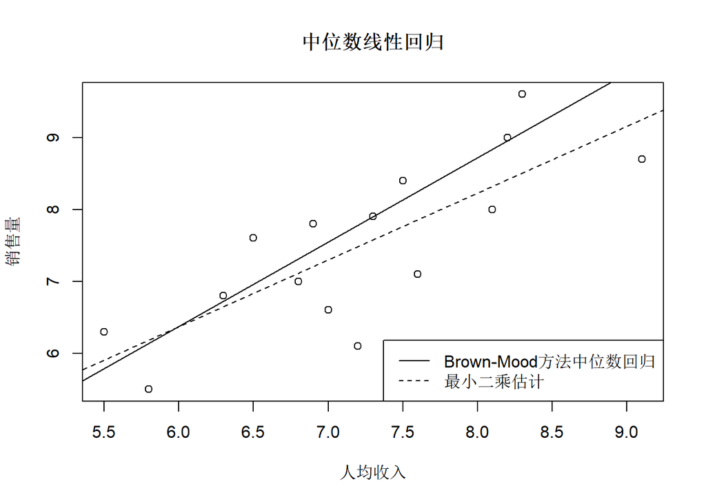

```r
#画图
plot(income,sale, xlab = "人均收入", ylab = "销售量", main = "中位数线性回归")
#实线为中位数回归直线
abline(alpha_BM, beta_BM)
#虚线为最小二乘估计
abline(c(cyx),lty=2)
#图例位置为右下角
legend("bottomright", legend = c("Brown-Mood方法中位数回归","最小二乘估计"),
              lty=c(1,2))
```

图中实线为Brown-Mood方法得到的中位数回归直线，虚线为最小二乘估计的回归直线。

Brown-Mood方法得到的中位数回归直线为$销售量=-0.6586207 + 1.172414×收入$

最小二乘估计的回归方程为$销售量=0.7995749 + 0.9288286×收入$

从图上看可以看到，最小二乘估计的回归方程的斜率小于中位数回归，偏离了主体数据的走向，原因是受到了直线下方部分异常数据的影响，即最小二乘估计对异常值更敏感。

## 2.Theil方法

自变量 $X$ 中没有重复数据时, 任给 $i<j,$ 记 $s_{i j}=\frac{Y_{j}-Y_{i}}{X_{j}-X_{i}},$ 则回归直线的斜率 $\beta$ 的估计为

$$\tilde{\beta}_{T}=\operatorname{median}\left\{s_{i j}: 1 \leqslant i<j \leqslant n\right\}$$

回归直线在 $Y$ 轴上的截距 $\alpha$ 的估计值为

$$\tilde{\alpha}_{T}=\operatorname{median}\left\{Y_{j}-\tilde{\beta}_{T} X_{j}: j=1,2, \cdots, n\right\}$$

```r
n <- length(sale)
sij <- NULL
#计算sij
for(i in 1:n-1){
  for(j in (i+1):n){
    sij <- c(sij, (sale[j]-sale[i])/(income[j]-income[i]))
  }
}
#β_T是所有sij的中位数
beta_T <- median(sij)
beta_T
```

```
## [1] 0.969697
```

```r
alpha_T <- median(sale - beta_T*income)
alpha_T
```

```
## [1] 0.6909091
```

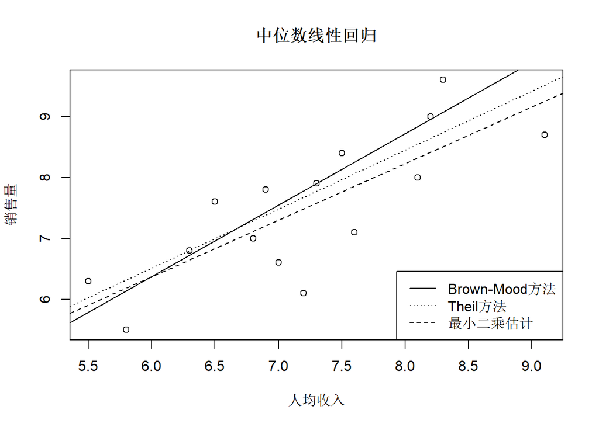

```r
#画图
plot(income,sale, xlab = "人均收入", ylab = "销售量", main = "中位数线性回归")
#实线为Brown-Mood方法得到的中位数回归直线
abline(alpha_BM, beta_BM)
#虚线为最小二乘估计
abline(c(cyx),lty=2)
#点虚线为Theil方法得到中位数回归直线
abline(alpha_T, beta_T,lty=3)
#图例位置为右下角
legend("bottomright", legend = c("Brown-Mood方法", "Theil方法", "最小二乘估计"),
              lty=c(1,3,2))
```

Theil方法得到的中位数回归直线为$销售量=0.6909091 + 0.969697×收入$

Theil方法也可以用`RobustLinearReg`包中的`theil_sen_regression()`函数计算，得到的结果相同。

```r
library(RobustLinearReg)
summary(theil_sen_regression(sale~income))
```

```
##
## Call:
## theil_sen_regression(formula = sale ~ income)
##
## Residuals:
##     Min      1Q  Median      3Q     Max
## -1.5727 -0.8152  0.0000  0.3879  0.8606
##
## Coefficients:
##             Estimate Std. Error t value Pr(>|t|)
## (Intercept)   0.6909     1.5191   0.455 0.656752
## income        0.9697     0.2090   4.639 0.000463 ***
## ---
## Signif. codes:  0 '***' 0.001 '**' 0.01 '*' 0.05 '.' 0.1 ' ' 1
##
## Residual standard error: 0.7631 on 13 degrees of freedom
## Multiple R-squared:  0.6234, Adjusted R-squared:  0.5945
## F-statistic: 21.52 on 1 and 13 DF,  p-value: 0.0004634
```

# 6.3 多变量Kendall协和系数检验

原假设与备择假设为：

$H_0$:12位裁判的打分不一致(不相关)；

$H_1$:12位裁判的打分一致(相关)；

以下进行多变量Kendall协和系数检验。

## 1.根据公式计算

这里的样本中有结，Kendall协和系数为

$$\begin{aligned}
W_{\mathrm{c}}=& \frac{\sum^{n} R_{i .}^{2}-\left(\sum R_{i}\right)^{2} / n}{\frac{k^{2}\left(n^{3}-n\right)-k \sum T}{12}} \\
&=\frac{12 \sum R_{i .}^{2}-3 k^{2} n(n+1)^{2}}{k^{2}\left(n^{3}-n\right)-k \sum\left(\tau_{i}^{3}-\tau_{i}\right)}
\end{aligned}$$
式中, $\tau_{i}$ 为结长, $g$ 为结的个数.

```r
#歌手成绩.csv与题给数据的行和列相同
#即每一列是一个歌手的成绩，共10位歌手；#每一行是一个裁判的打分，共12位裁判
ratings <- read.csv("D:/data/歌手成绩.csv", header = TRUE)
#转置
#转置后，每一列是一个裁判的打分，共12位裁判；每一行是一个歌手的成绩，共10位歌手
ratings <- t(ratings)
#n=10，10个歌手
n <- nrow(ratings)
#k=12，12个裁判
k <- ncol(ratings)
#样本中有结
#秩
ratings.rank <- apply(ratings,2,rank)
#计算T的和
T_sum <- 0
for (i in 1:k) {
    rater <- table(ratings.rank[,i])
    ties <- rater[rater>1]
    l <- as.numeric(ties)
    T_sum <- T_sum + sum(l^3-l)
    }
#根据公式计算样本中有结时的Kendall协和系数Wc
Wc <- (12*var(apply(ratings.rank,1,sum))*(n-1))/(k^2*(n^3-n)-k*T_sum)
#检验统计量
Xvalue <- k*(n-1)*Wc
#自由度
df <- n-1
#p值
p.value <- pchisq(Xvalue, df, lower.tail = FALSE)
p.value
```

```
## [1] 0.0001230086
```

## 2.使用KendallW()函数和kendall()函数

也可以用`DescTools`包中的`KendallW()`函数，`irr`包中的`kendall()`函数来计算。

由于样本中有结，因此设置`correct=TRUE`；

得到的结果一致。

```r
DescTools::KendallW(ratings, correct = TRUE, test = TRUE)
```

```
##
##  Kendall's coefficient of concordance Wt
##
## data:  ratings
## Kendall chi-squared = 33.205, df = 9, subjects = 10, raters = 12,
## p-value = 0.000123
## alternative hypothesis: Wt is greater 0
## sample estimates:
##        Wt
## 0.3074537
```

```r
irr::kendall(ratings, correct = TRUE)
```

```
##  Kendall's coefficient of concordance Wt
##
##  Subjects = 10
##    Raters = 12
##        Wt = 0.307
##
##  Chisq(9) = 33.2
##   p-value = 0.000123
```

p-value = 0.000123<0.05，拒绝原假设，认为裁判的打分是一致的。